# Deep Neural Networks: Bank Churn prediction

## Problem Statement

### Context

Businesses like banks which provide service have to worry about problem of 'Customer Churn' i.e. customers leaving and joining another service provider. It is important to understand which aspects of the service influence a customer's decision in this regard. Management can concentrate efforts on improvement of service, keeping in mind these priorities.

### Objective

To help the operations team identify the customers that are more likely to churn by building an artificial Neural Network from scratch, that can determine whether a customer will leave the bank or not in the next 6 months.

### Data Dictionary

- CustomerId: Unique ID which is assigned to each customer
- Surname: Last name of the customer
- CreditScore: It defines the credit history of the customer.
- Geography: A customer’s location
- Gender: It defines the Gender of the customer
- Age: Age of the customer
- Tenure: Number of years for which the customer has been with the bank
- NumOfProducts: refers to the number of products that a customer has purchased through the bank.
- Balance: Account balance
- HasCrCard: It is a categorical variable which decides whether the customer has credit card or not.
- EstimatedSalary: Estimated salary
- isActiveMember: Is is a categorical variable which decides whether the customer is active member of the bank or not ( Active member in the sense, using bank products regularly, making transactions etc )
- Exited : whether or not the customer left the bank within six month. It can take two values **0=No ( Customer did not leave the bank )** 1=Yes ( Customer left the bank )

## Importing necessary libraries

```python
# Libraries to help with reading and manipulating data
import pandas as pd
import numpy as np

# Library to split data
from sklearn.model_selection import train_test_split

# Library to encode the variables
from sklearn import preprocessing

# To plot confusion matrix
from sklearn.metrics import confusion_matrix

# libaries to help with data visualization
import matplotlib.pyplot as plt

%matplotlib inline
import seaborn as sns

sns.set(
    color_codes=True
)  # -----This adds a background color to all the plots created using seaborn

# Allow the use of Display via interactive Python
from IPython.display import display

# Import tabulate. library used for creating tables in a visually appealing format.
from tabulate import tabulate

# library to import to standardize the data
from sklearn.preprocessing import StandardScaler

# To import different metrics
from sklearn import metrics

# To supress scientific notations for a dataframe
pd.set_option("display.float_format", lambda x: "%.3f" % x)

# Library to avoid the warnings
import warnings

warnings.filterwarnings("ignore")

# importing different functions to build models
from tensorflow.keras.models import Sequential
from tensorflow.keras.layers import Dense, Dropout
from tensorflow.keras.wrappers.scikit_learn import KerasClassifier
import tensorflow as tf

from tensorflow.keras import backend

from keras.optimizers import SGD, Adam

# importing GridSearch CV
from sklearn.model_selection import GridSearchCV

# importing RandomizedSearch CV
from sklearn.model_selection import RandomizedSearchCV

# importing roc_curve to plot
from sklearn.metrics import roc_curve
from matplotlib import pyplot

# importing SMOTE
from imblearn.over_sampling import SMOTE

# Help gwenerate random number
import random

# Importing classback API
from keras import callbacks

# Making the Python code more structured automatically
%load_ext nb_black

print("Loading Libraries... Done.")
```

```
2023-07-15 16:53:31.070375: I tensorflow/core/platform/cpu_feature_guard.cc:193] This TensorFlow binary is optimized with oneAPI Deep Neural Network Library (oneDNN) to use the following CPU instructions in performance-critical operations:  SSE4.1 SSE4.2
To enable them in other operations, rebuild TensorFlow with the appropriate compiler flags.
```

```
Loading Libraries... Done.
```

```python
# from google.colab import drive
# drive.mount('/content/drive')
```

## Loading the dataset

```python
# Loading Dataset
data_path = "Churn.csv"
data = pd.read_csv(data_path)

# Making a copy of the data to avoid any changes to original data
df = data.copy()

print("Loading Dataset... Done.")
```

```
Loading Dataset... Done.
```

## Data Overview

### Checking a few rows of the dataset.

```python
# Checking the top 5, botom 5 and 10 random rows

display(df.head())  # -----looking at head (top 5 observations)
display(df.tail())  # -----looking at tail (bottom 5 observations)
display(
    df.sample(7, random_state=1)
)  # -----7 random sample of observations from the data
```

|  | RowNumber | CustomerId | Surname | CreditScore | Geography | Gender | Age | Tenure | Balance | NumOfProducts | HasCrCard | IsActiveMember | EstimatedSalary | Exited |
| --- | --- | --- | --- | --- | --- | --- | --- | --- | --- | --- | --- | --- | --- | --- |
| 0 | 1 | 15634602 | Hargrave | 619 | France | Female | 42 | 2 | 0.000 | 1 | 1 | 1 | 101348.880 | 1 |
| 1 | 2 | 15647311 | Hill | 608 | Spain | Female | 41 | 1 | 83807.860 | 1 | 0 | 1 | 112542.580 | 0 |
| 2 | 3 | 15619304 | Onio | 502 | France | Female | 42 | 8 | 159660.800 | 3 | 1 | 0 | 113931.570 | 1 |
| 3 | 4 | 15701354 | Boni | 699 | France | Female | 39 | 1 | 0.000 | 2 | 0 | 0 | 93826.630 | 0 |
| 4 | 5 | 15737888 | Mitchell | 850 | Spain | Female | 43 | 2 | 125510.820 | 1 | 1 | 1 | 79084.100 | 0 |

|  | RowNumber | CustomerId | Surname | CreditScore | Geography | Gender | Age | Tenure | Balance | NumOfProducts | HasCrCard | IsActiveMember | EstimatedSalary | Exited |
| --- | --- | --- | --- | --- | --- | --- | --- | --- | --- | --- | --- | --- | --- | --- |
| 9995 | 9996 | 15606229 | Obijiaku | 771 | France | Male | 39 | 5 | 0.000 | 2 | 1 | 0 | 96270.640 | 0 |
| 9996 | 9997 | 15569892 | Johnstone | 516 | France | Male | 35 | 10 | 57369.610 | 1 | 1 | 1 | 101699.770 | 0 |
| 9997 | 9998 | 15584532 | Liu | 709 | France | Female | 36 | 7 | 0.000 | 1 | 0 | 1 | 42085.580 | 1 |
| 9998 | 9999 | 15682355 | Sabbatini | 772 | Germany | Male | 42 | 3 | 75075.310 | 2 | 1 | 0 | 92888.520 | 1 |
| 9999 | 10000 | 15628319 | Walker | 792 | France | Female | 28 | 4 | 130142.790 | 1 | 1 | 0 | 38190.780 | 0 |

|  | RowNumber | CustomerId | Surname | CreditScore | Geography | Gender | Age | Tenure | Balance | NumOfProducts | HasCrCard | IsActiveMember | EstimatedSalary | Exited |
| --- | --- | --- | --- | --- | --- | --- | --- | --- | --- | --- | --- | --- | --- | --- |
| 9953 | 9954 | 15655952 | Burke | 550 | France | Male | 47 | 2 | 0.000 | 2 | 1 | 1 | 97057.280 | 0 |
| 3850 | 3851 | 15775293 | Stephenson | 680 | France | Male | 34 | 3 | 143292.950 | 1 | 1 | 0 | 66526.010 | 0 |
| 4962 | 4963 | 15665088 | Gordon | 531 | France | Female | 42 | 2 | 0.000 | 2 | 0 | 1 | 90537.470 | 0 |
| 3886 | 3887 | 15720941 | Tien | 710 | Germany | Male | 34 | 8 | 147833.300 | 2 | 0 | 1 | 1561.580 | 0 |
| 5437 | 5438 | 15733476 | Gonzalez | 543 | Germany | Male | 30 | 6 | 73481.050 | 1 | 1 | 1 | 176692.650 | 0 |
| 8517 | 8518 | 15671800 | Robinson | 688 | France | Male | 20 | 8 | 137624.400 | 2 | 1 | 1 | 197582.790 | 0 |
| 2041 | 2042 | 15709846 | Yeh | 840 | France | Female | 39 | 1 | 94968.970 | 1 | 1 | 0 | 84487.620 | 0 |

### Understand the shape of the dataset

```python
# -----Print the dimension of the data
print(f"There are {df.shape[0]} rows and {df.shape[1]} columns")
```

```
There are 10000 rows and 14 columns
```

### Checking the Data Types & General Information of the Dataset

```python
# -----Displaying information about features of the Dataset
df.info()
```

```
<class 'pandas.core.frame.DataFrame'>
RangeIndex: 10000 entries, 0 to 9999
Data columns (total 14 columns):
 #   Column           Non-Null Count  Dtype
---  ------           --------------  -----
 0   RowNumber        10000 non-null  int64
 1   CustomerId       10000 non-null  int64
 2   Surname          10000 non-null  object
 3   CreditScore      10000 non-null  int64
 4   Geography        10000 non-null  object
 5   Gender           10000 non-null  object
 6   Age              10000 non-null  int64
 7   Tenure           10000 non-null  int64
 8   Balance          10000 non-null  float64
 9   NumOfProducts    10000 non-null  int64
 10  HasCrCard        10000 non-null  int64
 11  IsActiveMember   10000 non-null  int64
 12  EstimatedSalary  10000 non-null  float64
 13  Exited           10000 non-null  int64
dtypes: float64(2), int64(9), object(3)
memory usage: 1.1+ MB
```

### Checking the Statistical Summary

#### For Numerical Features

```python
# -----Displaying Statistical Summary of Numerical Data
df.describe().T
```

|  | count | mean | std | min | 25% | 50% | 75% | max |
| --- | --- | --- | --- | --- | --- | --- | --- | --- |
| RowNumber | 10000.000 | 5000.500 | 2886.896 | 1.000 | 2500.750 | 5000.500 | 7500.250 | 10000.000 |
| CustomerId | 10000.000 | 15690940.569 | 71936.186 | 15565701.000 | 15628528.250 | 15690738.000 | 15753233.750 | 15815690.000 |
| CreditScore | 10000.000 | 650.529 | 96.653 | 350.000 | 584.000 | 652.000 | 718.000 | 850.000 |
| Age | 10000.000 | 38.922 | 10.488 | 18.000 | 32.000 | 37.000 | 44.000 | 92.000 |
| Tenure | 10000.000 | 5.013 | 2.892 | 0.000 | 3.000 | 5.000 | 7.000 | 10.000 |
| Balance | 10000.000 | 76485.889 | 62397.405 | 0.000 | 0.000 | 97198.540 | 127644.240 | 250898.090 |
| NumOfProducts | 10000.000 | 1.530 | 0.582 | 1.000 | 1.000 | 1.000 | 2.000 | 4.000 |
| HasCrCard | 10000.000 | 0.706 | 0.456 | 0.000 | 0.000 | 1.000 | 1.000 | 1.000 |
| IsActiveMember | 10000.000 | 0.515 | 0.500 | 0.000 | 0.000 | 1.000 | 1.000 | 1.000 |
| EstimatedSalary | 10000.000 | 100090.240 | 57510.493 | 11.580 | 51002.110 | 100193.915 | 149388.247 | 199992.480 |
| Exited | 10000.000 | 0.204 | 0.403 | 0.000 | 0.000 | 0.000 | 0.000 | 1.000 |

#### For Categorical Features

```python
# -----Displaying the Summary of Categorical Data
df.describe(include=["object"]).T
```

|  | count | unique | top | freq |
| --- | --- | --- | --- | --- |
| Surname | 10000 | 2932 | Smith | 32 |
| Geography | 10000 | 3 | France | 5014 |
| Gender | 10000 | 2 | Male | 5457 |

```python
# Get the Categorical Variables (Object types)
cat_cols = df.select_dtypes(["object"])

# Check the unique values of the categorical variables
for i in cat_cols.columns:
    print("Unique values % in", i, "are :")
    print(cat_cols[i].value_counts(normalize=True) * 100)
    print("*" * 50)
    print("\n")
```

```
Unique values % in Surname are :
Smith      0.320
Scott      0.290
Martin     0.290
Walker     0.280
Brown      0.260
            ...
Izmailov   0.010
Bold       0.010
Bonham     0.010
Poninski   0.010
Burbidge   0.010
Name: Surname, Length: 2932, dtype: float64


Unique values % in Geography are :
France    50.140
Germany   25.090
Spain     24.770
Name: Geography, dtype: float64


Unique values % in Gender are :
Male     54.570
Female   45.430
Name: Gender, dtype: float64
```

### Checking for Missing & Duplicate Values

```python
# Checking missing values across each columns

c_missing = pd.Series(df.isnull().sum(), name="Missing Count")  # -----Count Missing

p_missing = pd.Series(
    round(df.isnull().sum() / df.shape[0] * 100, 2), name="% Missing"
)  # -----Percentage Missing


# Combine into 1 Dataframe
missing_df = pd.concat([c_missing, p_missing], axis=1)

# # Display missing info
# display(missing_df)

missing_df.sort_values(by="% Missing", ascending=False).style.background_gradient(
    cmap="YlOrRd"
)
```

|  | Missing Count | % Missing |
| --- | --- | --- |
| RowNumber | 0 | 0.000000 |
| CustomerId | 0 | 0.000000 |
| Surname | 0 | 0.000000 |
| CreditScore | 0 | 0.000000 |
| Geography | 0 | 0.000000 |
| Gender | 0 | 0.000000 |
| Age | 0 | 0.000000 |
| Tenure | 0 | 0.000000 |
| Balance | 0 | 0.000000 |
| NumOfProducts | 0 | 0.000000 |
| HasCrCard | 0 | 0.000000 |
| IsActiveMember | 0 | 0.000000 |
| EstimatedSalary | 0 | 0.000000 |
| Exited | 0 | 0.000000 |

```python
# Checking for duplicate records

df.duplicated().sum()
```

```
0
```

### Drop the Columns which are unique for all users

```python
# Drop the columns which are unique for all users
# because they will not add any value to our model and analysis.

df = df.drop(["RowNumber", "CustomerId", "Surname"], axis=1)
```

```python
df.info()
```

```
<class 'pandas.core.frame.DataFrame'>
RangeIndex: 10000 entries, 0 to 9999
Data columns (total 11 columns):
 #   Column           Non-Null Count  Dtype
---  ------           --------------  -----
 0   CreditScore      10000 non-null  int64
 1   Geography        10000 non-null  object
 2   Gender           10000 non-null  object
 3   Age              10000 non-null  int64
 4   Tenure           10000 non-null  int64
 5   Balance          10000 non-null  float64
 6   NumOfProducts    10000 non-null  int64
 7   HasCrCard        10000 non-null  int64
 8   IsActiveMember   10000 non-null  int64
 9   EstimatedSalary  10000 non-null  float64
 10  Exited           10000 non-null  int64
dtypes: float64(2), int64(7), object(2)
memory usage: 859.5+ KB
```

**Observations**

## Exploratory Data Analysis

##### User Defined Functions

```python
# -----
# User defined function to prints the 5 point summary and histogram, box plot,
#   and cumulative density distribution plots
# -----


def summary(data, x):
    """
    The function prints the 5 point summary and histogram, box plot,
    and cumulative density distribution plots for each
    feature name passed as the argument.

    Parameters:
    ----------

    x: str, feature name

    Usage:
    ------------

    summary('age')
    """

    x_min = data[x].min()
    x_max = data[x].max()
    Q1 = data[x].quantile(0.25)
    Q2 = data[x].quantile(0.50)
    Q3 = data[x].quantile(0.75)

    dict = {"Min": x_min, "Q1": Q1, "Q2": Q2, "Q3": Q3, "Max": x_max}
    ldf = pd.DataFrame(data=dict, index=["Value"])
    print(f"5 Point Summary of {x.capitalize()} Attribute:\n")
    print(tabulate(ldf, headers="keys", tablefmt="psql"))

    fig, axs = plt.subplots(nrows=3, ncols=1, figsize=(16, 22))
    sns.set_palette("Pastel1")

    # Histogram
    ax1 = sns.distplot(data[x], color="purple", ax=axs[0])
    ax1.axvline(np.mean(data[x]), color="purple", linestyle="--")
    ax1.axvline(np.median(data[x]), color="black", linestyle="-")
    ax1.set_title(f"{x.capitalize()} Density Distribution")

    # Boxplot
    ax2 = sns.boxplot(
        x=data[x], palette="cool", width=0.7, linewidth=0.6, showmeans=True, ax=axs[1]
    )
    ax2.set_title(f"{x.capitalize()} Boxplot")

    # Cummulative plot
    ax3 = sns.kdeplot(data[x], cumulative=True, linewidth=1.5, ax=axs[2])
    ax3.set_title(f"{x.capitalize()} Cumulative Density Distribution")

    plt.subplots_adjust(hspace=0.4)
    plt.show()
```

```python
# -----
# User defined function to plot labeled_barplot
# -----


def labeled_barplot(data, feature, perc=False, v_ticks=True, n=None):
    """
    Barplot with percentage at the top

    data: dataframe
    feature: dataframe column
    perc: whether to display percentages instead of count (default is False)
    n: displays the top n category levels (default is None, i.e., display all levels)
    """

    total = len(data[feature])  # length of the column
    count = data[feature].nunique()
    if n is None:
        plt.figure(figsize=(count + 1, 5))
    else:
        plt.figure(figsize=(n + 1, 5))

    if v_ticks is True:
        plt.xticks(rotation=90)

    ax = sns.countplot(
        data=data,
        x=feature,
        palette="Paired",
        order=data[feature].value_counts().index[:n].sort_values(),
    )

    for p in ax.patches:
        if perc == True:
            label = "{:.1f}%".format(
                100 * p.get_height() / total
            )  # percentage of each class of the category
        else:
            label = p.get_height()  # count of each level of the category

        x = p.get_x() + p.get_width() / 2  # width of the plot
        y = p.get_height()  # height of the plot

        ax.annotate(
            label,
            (x, y),
            ha="center",
            va="center",
            size=12,
            xytext=(0, 5),
            textcoords="offset points",
        )  # annotate the percentage
    plt.show()  # show the plot
```

```python
# -----
# User defined function to plot stacked bar chart
# -----


def stacked_barplot(data, predictor, target):
    """
    Print the category counts and plot a stacked bar chart

    data: dataframe
    predictor: independent variable
    target: target variable
    """
    count = data[predictor].nunique()
    sorter = data[target].value_counts().index[-1]
    tab1 = pd.crosstab(data[predictor], data[target], margins=True).sort_values(
        by=sorter, ascending=False
    )
    print(tab1)
    print("-" * 80)
    tab = pd.crosstab(data[predictor], data[target], normalize="index").sort_values(
        by=sorter, ascending=False
    )
    tab.plot(kind="bar", stacked=True, figsize=(count + 1, 5))
    plt.legend(
        loc="lower left",
        frameon=False,
    )
    plt.legend(loc="upper left", bbox_to_anchor=(1, 1))
    plt.show()
```

```python
# -----
# User defined function to plot both kde & boxplot of predictor variable wrt target
# -----


def kde_boxplot_wrt_target(data, predictor, target):
    # Create the BoxPlot
    plt.figure(figsize=(15, 5))
    sns.boxplot(data=data, x=target, y=predictor, showmeans=True)
    plt.tight_layout()
    plt.show()

    # Create the KDE plot with hue
    sns.kdeplot(
        data=data,
        x=predictor,
        hue=target,
        fill=True,
    )
    # Add labels and title
    plt.xlabel(predictor)
    plt.ylabel("Density")
```

### Univariate Analysis

#### Observations on CreditScore

```
5 Point Summary of Creditscore Attribute:

+-------+-------+------+------+------+-------+
|       |   Min |   Q1 |   Q2 |   Q3 |   Max |
|-------+-------+------+------+------+-------|
| Value |   350 |  584 |  652 |  718 |   850 |
+-------+-------+------+------+------+-------+
```

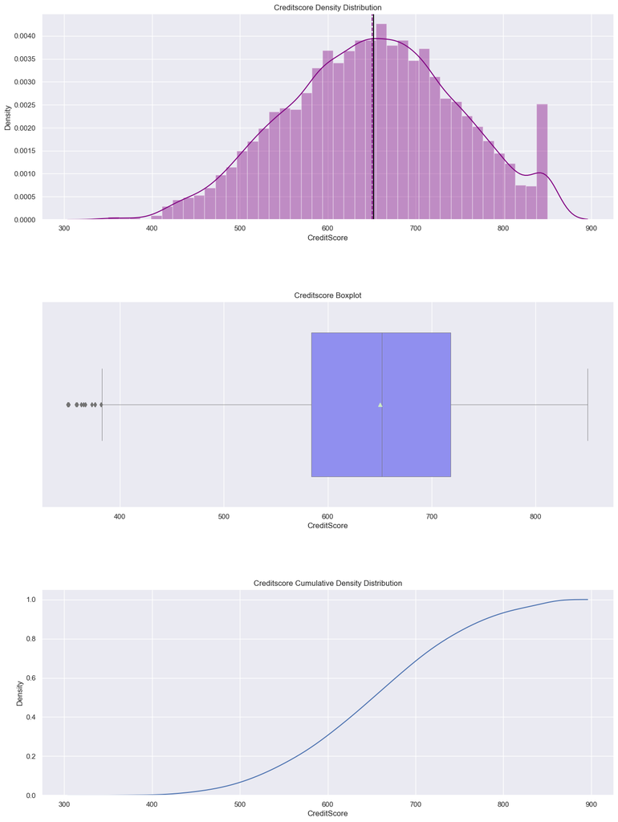

```python
# -----Plot Histogram, Box plot and Cummulative Plot
summary(df, "CreditScore")
```

**Observations**

- The data looks somewhat normally distributed.
- There are some outliers to the left.
- About 90% of the customers have credit scores that is lower than 800.

#### Observations on Age

```
5 Point Summary of Age Attribute:

+-------+-------+------+------+------+-------+
|       |   Min |   Q1 |   Q2 |   Q3 |   Max |
|-------+-------+------+------+------+-------|
| Value |    18 |   32 |   37 |   44 |    92 |
+-------+-------+------+------+------+-------+
```

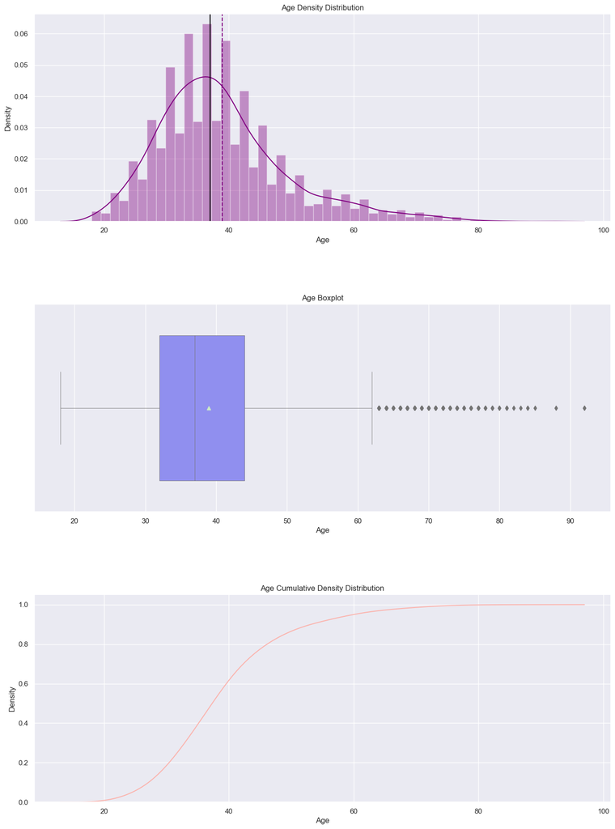

```python
# -----Plot Histogram, Box plot and Cummulative Plot
summary(df, "Age")
```

**Observations**

- `Age` looks rightly skewed.
- There are some outliers to the right.
- 90% of the customers are younger than 60.

#### Observations on Balance

```
5 Point Summary of Balance Attribute:

+-------+-------+------+---------+--------+--------+
|       |   Min |   Q1 |      Q2 |     Q3 |    Max |
|-------+-------+------+---------+--------+--------|
| Value |     0 |    0 | 97198.5 | 127644 | 250898 |
+-------+-------+------+---------+--------+--------+
```

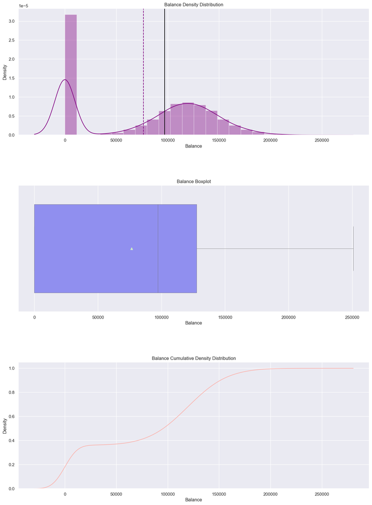

```python
# -----Plot Histogram, Box plot and Cummulative Plot
summary(df, "Balance")
```

**Observations**

#### Observations on Estimated Salary

```
5 Point Summary of Estimatedsalary Attribute:

+-------+-------+---------+--------+--------+--------+
|       |   Min |      Q1 |     Q2 |     Q3 |    Max |
|-------+-------+---------+--------+--------+--------|
| Value | 11.58 | 51002.1 | 100194 | 149388 | 199992 |
+-------+-------+---------+--------+--------+--------+
```

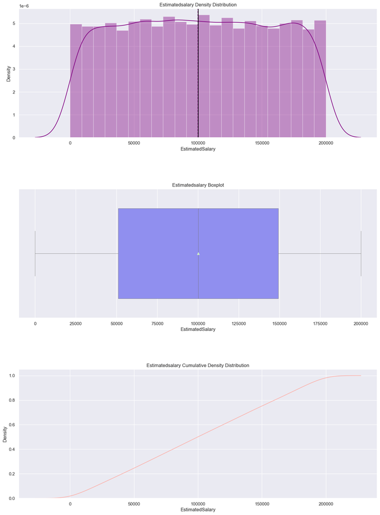

```python
# -----Plot Histogram, Box plot and Cummulative Plot
summary(df, "EstimatedSalary")
```

**Observations**

- `EstimatedSalary` appears to have a uniform distribution.
- Mean and median are the same value.
- There are no outliers.

#### Observations on Exited

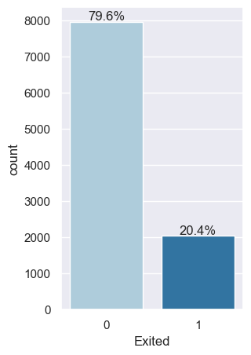

```python
# -----Call the label_barplot function to plot the graph
labeled_barplot(df, "Exited", True, False)
```

**Observations**

- The Target variable `Exited` is imbalanced with 80% non-Exited.
- We will address this imbalance in our model building to see the impact on our metrics.

#### Observations on Geography

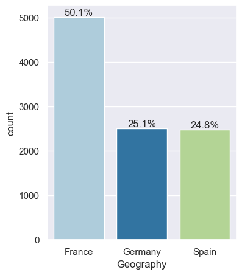

```python
# -----Call the label_barplot function to plot the graph
labeled_barplot(df, "Geography", True, False)
```

**Observations**

#### Observations on Gender

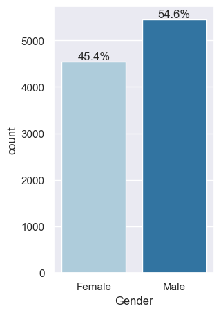

```python
# -----Call the label_barplot function to plot the graph
labeled_barplot(df, "Gender", True, False)
```

**Observations**

- About 55% of the cusmers are male and 45% female.

#### Observations on Tenure

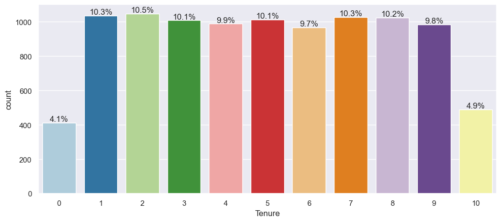

```python
# -----Call the label_barplot function to plot the graph
labeled_barplot(df, "Tenure", True, False)
```

**Observations**

- `Tenure` 1-9 have about 10% of the customers each.

#### Observations on Number of Products

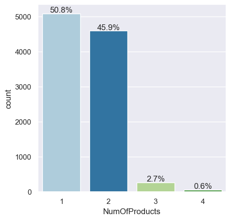

```python
# -----Call the label_barplot function to plot the graph
labeled_barplot(df, "NumOfProducts", True, False)
```

**Observations**

- About 97% of the customers have 1 or 2 products from the bank.
- 2.7% has 3 products and 0.6% has 4.

#### Observations on Has Credit Card

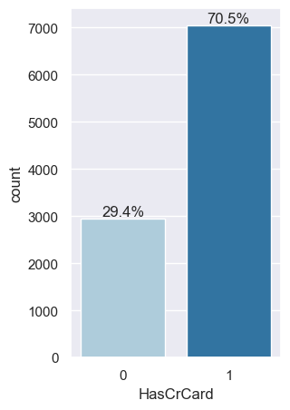

```python
# -----Call the label_barplot function to plot the graph
labeled_barplot(df, "HasCrCard", True, False)
```

**Observations**

- About 71% of the customers have a credit card and about 29% do not.

#### Observations on Is Active Member

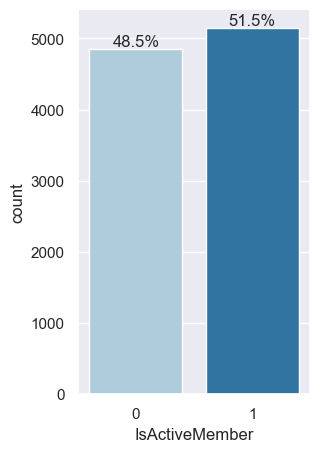

```python
# -----Call the label_barplot function to plot the graph
labeled_barplot(df, "IsActiveMember", True, False)
```

**Observations**

- About half of the customers are inactive.

### Bivariate Analysis

#### Correlation plot

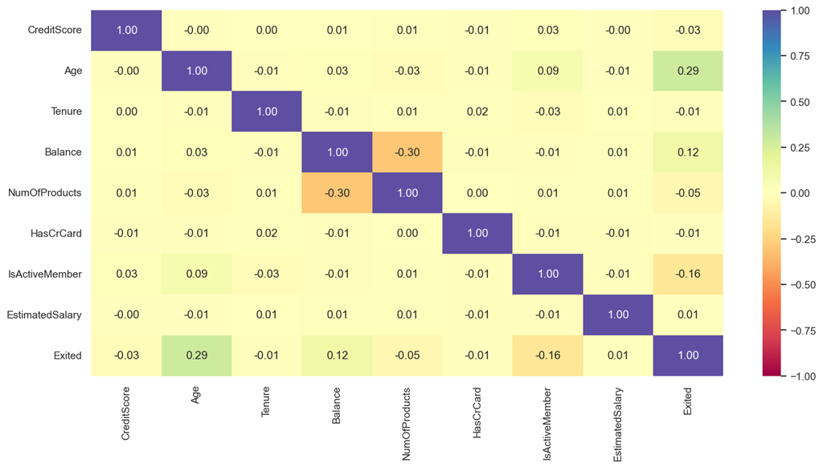

```python
plt.figure(figsize=(15, 7))
sns.heatmap(df.corr(), annot=True, vmin=-1, vmax=1, fmt=".2f", cmap="Spectral")
plt.show()
```

**Observations**

- None of the features are strongly correlated.

#### Exited Vs Geography

```
Exited        0     1    All
Geography
All        7963  2037  10000
Germany    1695   814   2509
France     4204   810   5014
Spain      2064   413   2477
--------------------------------------------------------------------------------
```

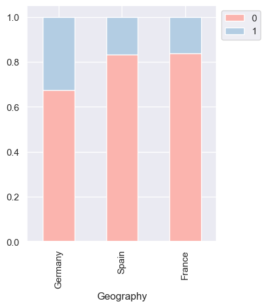

```python
# Stacked Barplot comparison with Target variable
stacked_barplot(df, "Geography", "Exited")
```

**Observations**

- About 32% of Germans customers Exited.
- About 16% of customers Exited from Spain and France each.

#### Exited Vs Gender

```
Exited     0     1    All
Gender
All     7963  2037  10000
Female  3404  1139   4543
Male    4559   898   5457
--------------------------------------------------------------------------------
```

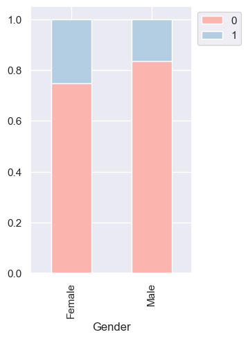

```python
# Stacked Barplot comparison with Target variable
stacked_barplot(df, "Gender", "Exited")
```

**Observations**

- More female customers exited.

#### Exited Vs Has Credit Card

```
Exited        0     1    All
HasCrCard
All        7963  2037  10000
1          5631  1424   7055
0          2332   613   2945
--------------------------------------------------------------------------------
```

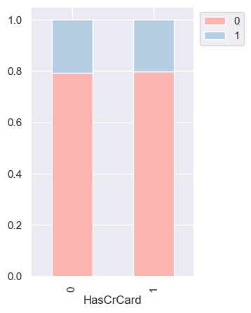

```python
# Stacked Barplot comparison with Target variable
stacked_barplot(df, "HasCrCard", "Exited")
```

**Observations**

- There's no difference between if the customers have a Credit Card or not.

#### Exited Vs Is active member

```
Exited             0     1    All
IsActiveMember
All             7963  2037  10000
0               3547  1302   4849
1               4416   735   5151
--------------------------------------------------------------------------------
```

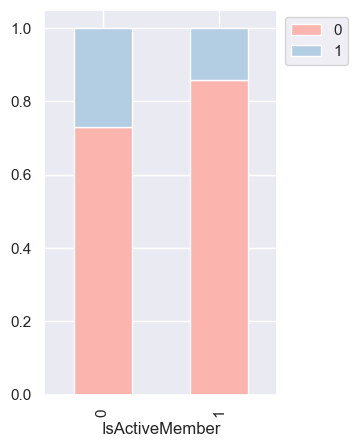

```python
# Stacked Barplot comparison with Target variable
stacked_barplot(df, "IsActiveMember", "Exited")
```

**Observations**

- As expected, about twice as many inactive Customers Exited.

#### Exited Vs Credit Score

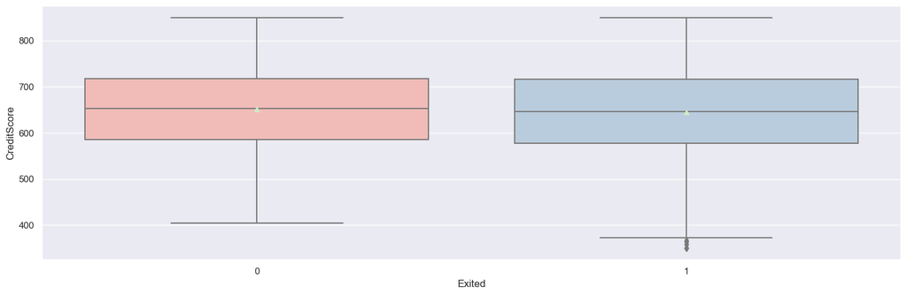

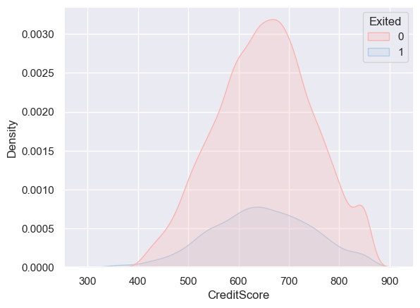

```python
# KDE & Boxplot with respect to Exited
kde_boxplot_wrt_target(df, "CreditScore", "Exited")
```

**Observations**

- `CreditScore` does not apeear to impact on if a Customer exited or not.

#### Exited Vs Age

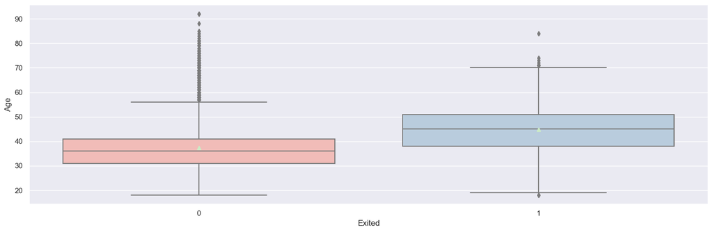

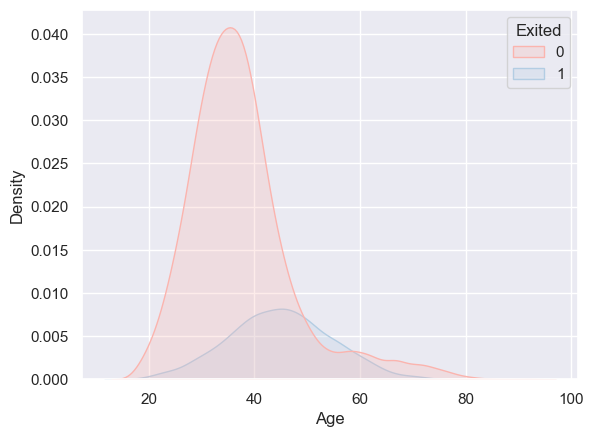

```python
# KDE & Boxplot with respect to Exited
kde_boxplot_wrt_target(df, "Age", "Exited")
```

**Observations**

- More older people `Exited`.

#### Exited Vs Tenure

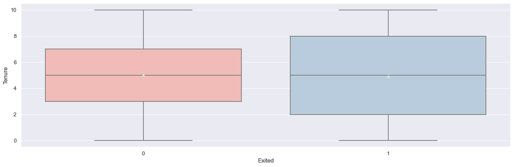

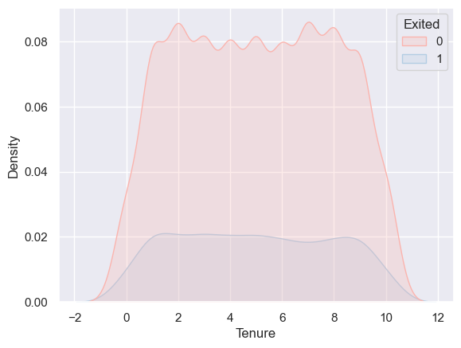

```python
# KDE & Boxplot with respect to Exited
kde_boxplot_wrt_target(df, "Tenure", "Exited")
```

**Observations**

- `Tenure` does not apeear to impact on if a Customer exited or not.

#### Exited Vs Balance

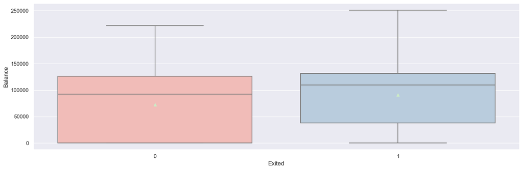

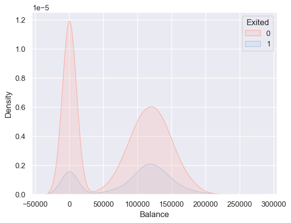

```python
# KDE & Boxplot with respect to Exited
kde_boxplot_wrt_target(df, "Balance", "Exited")
```

**Observations**

- It appears that more customers with higher bank `Balance` `Exited`.

#### Exited Vs Number of Products

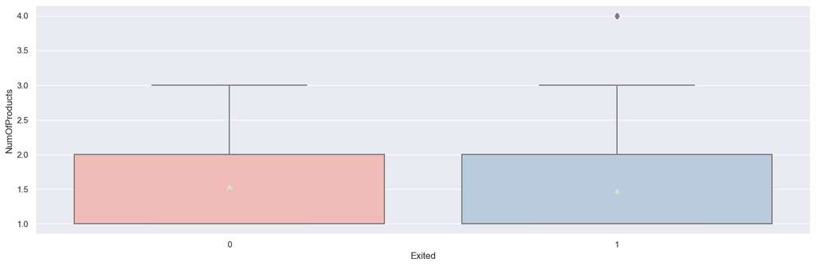

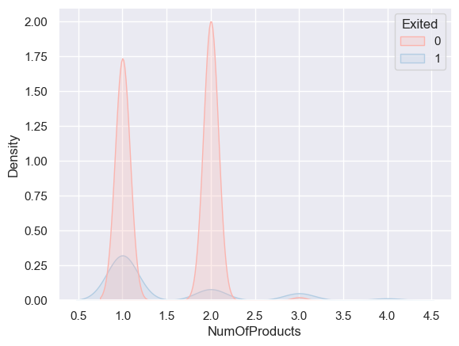

```python
# KDE & Boxplot with respect to Exited
kde_boxplot_wrt_target(df, "NumOfProducts", "Exited")
```

**Observations**

#### Exited Vs Estimated Salary

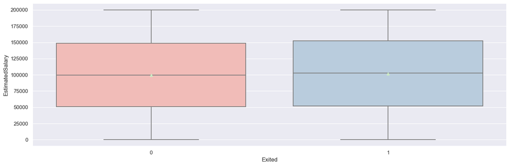

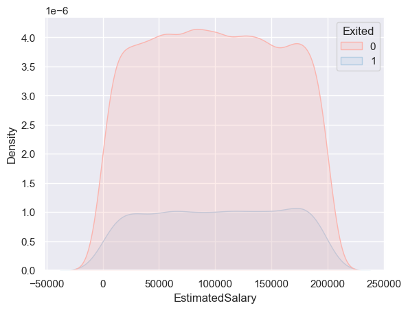

```python
# KDE & Boxplot with respect to Exited
kde_boxplot_wrt_target(df, "EstimatedSalary", "Exited")
```

**Observations**

- It appears that `EstimatedSalary` does not affect if a customer `Exited`.

## Data Preprocessing

### Feature Engineering

We will 3 new features: Balance to Salary Ratio; Tebure by Age ratio & CreditScore by Age

```python
# 1st Attribute - Balance Salary Ratio
df["BalanceSalaryRatio"] = df.Balance / df.EstimatedSalary

#  2nd Attribute-Tenure By Age
df["TenureByAge"] = df.Tenure / df.Age

# 3rd Attribute- Credit Score Given Age
df["CreditScoreByAge"] = df.CreditScore / df.Age
```

### Data Preparation for Modeling

```python
# Dividing dataset into X and y
X = df.drop(["Exited"], axis=1)
y = df[["Exited"]]
```

```python
# Splitting data into training, validation and test set:
# first we split data into 2 parts; temporary and test
# then we split temporary into; train and val

X_temp, X_test, y_temp, y_test = train_test_split(
    X, y, test_size=0.2, random_state=1, stratify=y, shuffle=True
)

# then we split the temporary set into train and validation
X_train, X_val, y_train, y_val = train_test_split(
    X_temp, y_temp, test_size=0.2, random_state=1, stratify=y_temp, shuffle=True
)
print(X_train.shape, X_val.shape, X_test.shape)
```

```
(6400, 13) (1600, 13) (2000, 13)
```

**Create dummy variables for Categorical variables**

```python
# Encoding Geography & Gender variables
X_train = pd.get_dummies(X_train, columns=["Geography", "Gender"], drop_first=True)
X_test = pd.get_dummies(X_test, columns=["Geography", "Gender"], drop_first=True)
X_val = pd.get_dummies(X_val, columns=["Geography", "Gender"], drop_first=True)
```

**Normalize the Numerical data**

```python
## Complete the below code to scale the data using standardscaler
sc = StandardScaler()
temp = sc.fit(
    X_train[
        [
            "CreditScore",
            "Age",
            "Tenure",
            "Balance",
            "EstimatedSalary",
            "BalanceSalaryRatio",
            "TenureByAge",
            "CreditScoreByAge",
        ]
    ]
)
X_train[
    [
        "CreditScore",
        "Age",
        "Tenure",
        "Balance",
        "EstimatedSalary",
        "BalanceSalaryRatio",
        "TenureByAge",
        "CreditScoreByAge",
    ]
] = temp.transform(
    X_train[
        [
            "CreditScore",
            "Age",
            "Tenure",
            "Balance",
            "EstimatedSalary",
            "BalanceSalaryRatio",
            "TenureByAge",
            "CreditScoreByAge",
        ]
    ]
)
X_test[
    [
        "CreditScore",
        "Age",
        "Tenure",
        "Balance",
        "EstimatedSalary",
        "BalanceSalaryRatio",
        "TenureByAge",
        "CreditScoreByAge",
    ]
] = temp.transform(
    X_test[
        [
            "CreditScore",
            "Age",
            "Tenure",
            "Balance",
            "EstimatedSalary",
            "BalanceSalaryRatio",
            "TenureByAge",
            "CreditScoreByAge",
        ]
    ]
)
X_val[
    [
        "CreditScore",
        "Age",
        "Tenure",
        "Balance",
        "EstimatedSalary",
        "BalanceSalaryRatio",
        "TenureByAge",
        "CreditScoreByAge",
    ]
] = temp.transform(
    X_val[
        [
            "CreditScore",
            "Age",
            "Tenure",
            "Balance",
            "EstimatedSalary",
            "BalanceSalaryRatio",
            "TenureByAge",
            "CreditScoreByAge",
        ]
    ]
)
```

## Model Building

### Model Evaluation Criterion

**The model can make wrong predictions as:**

1. Predicting a customer will Exit and the customer doesn't Exit. These are False Positives (FP) - Minimal loss of resources, if any.
2. Predicting a customer will not Exit and the customer Exits. These are False Negatives (FN) - Loss of Revenue.

**Which case is more important?**

- Predicting that customer will not Exit but he Exits i.e. losing on a valuable customer or asset and all the value that comes with that.

**How to reduce this loss i.e need to reduce False Negatives?**

- We know that the Recall (Sensitivity or True Positive Recal (TPR)) is expressed as $Recall Score=\dfrac{TP}{TP+FN}$.
- The company wants Recall to be maximized, the greater the Recall the lesser the chances of false negatives.
- The lower the FN the greater the Recall Score, the higher the chances of predicting correctly the customers that will Exit...and not wrongly predicting that a customer will not Exit when they will.

**Create a function for plotting the confusion matrix**

```python
def make_confusion_matrix(
    cf,
    group_names=None,
    categories="auto",
    count=True,
    percent=True,
    cbar=True,
    xyticks=True,
    xyplotlabels=True,
    sum_stats=True,
    figsize=None,
    cmap="Blues",
    title=None,
):
    """
    This function will make a pretty plot of an sklearn Confusion Matrix cm using a Seaborn heatmap visualization.
    Arguments
    """

    # CODE TO GENERATE TEXT INSIDE EACH SQUARE
    blanks = ["" for i in range(cf.size)]

    if group_names and len(group_names) == cf.size:
        group_labels = ["{}\n".format(value) for value in group_names]
    else:
        group_labels = blanks

    if count:
        group_counts = ["{0:0.0f}\n".format(value) for value in cf.flatten()]
    else:
        group_counts = blanks

    if percent:
        group_percentages = [
            "{0:.2%}".format(value) for value in cf.flatten() / np.sum(cf)
        ]
    else:
        group_percentages = blanks

    box_labels = [
        f"{v1}{v2}{v3}".strip()
        for v1, v2, v3 in zip(group_labels, group_counts, group_percentages)
    ]
    box_labels = np.asarray(box_labels).reshape(cf.shape[0], cf.shape[1])

    # CODE TO GENERATE SUMMARY STATISTICS & TEXT FOR SUMMARY STATS
    if sum_stats:
        # Accuracy is sum of diagonal divided by total observations
        accuracy = np.trace(cf) / float(np.sum(cf))

        # if it is a binary confusion matrix, show some more stats
        if len(cf) == 2:
            # Metrics for Binary Confusion Matrices
            precision = cf[1, 1] / sum(cf[:, 1])
            recall = cf[1, 1] / sum(cf[1, :])
            f1_score = 2 * precision * recall / (precision + recall)
            stats_text = "\n\nAccuracy={:0.3f}\nPrecision={:0.3f}\nRecall={:0.3f}\nF1 Score={:0.3f}".format(
                accuracy, precision, recall, f1_score
            )
        else:
            stats_text = "\n\nAccuracy={:0.3f}".format(accuracy)
    else:
        stats_text = ""

    # SET FIGURE PARAMETERS ACCORDING TO OTHER ARGUMENTS
    if figsize == None:
        # Get default figure size if not set
        figsize = plt.rcParams.get("figure.figsize")

    if xyticks == False:
        # Do not show categories if xyticks is False
        categories = False

    # MAKE THE HEATMAP VISUALIZATION
    plt.figure(figsize=figsize)
    sns.heatmap(
        cf,
        annot=box_labels,
        fmt="",
        cmap=cmap,
        cbar=cbar,
        xticklabels=categories,
        yticklabels=categories,
    )

    if xyplotlabels:
        plt.ylabel("True label")
        plt.xlabel("Predicted label" + stats_text)
    else:
        plt.xlabel(stats_text)

    if title:
        plt.title(title)
```

### Model 1: Neural Network

```python
backend.clear_session()
# Fixing the seed for random number generators so that we can ensure we receive the same output everytime
np.random.seed(1)
random.seed(1)
tf.random.set_seed(1)
```

```python
# Initializing the ANN
model1 = Sequential()
# 64 neurons with relu as activation function with input of 11 variables
model1.add(Dense(activation="relu", input_dim=14, units=64))

# Hidden layer with 32 neurons
model1.add(Dense(32, activation="relu"))

# Output layer with sigmoid activation function
model1.add(Dense(1, activation="sigmoid"))
```

```python
## Compiling the model with SGD optimizer and binary cross entropy as loss
## with accuracy as metrics and with default learning rate
model1.compile(optimizer="SGD", loss="binary_crossentropy", metrics=["Accuracy"])
```

```python
## Complete the code to obtain the summary of the model
model1.summary()
```

```
Model: "sequential"
_________________________________________________________________
 Layer (type)                Output Shape              Param #
=================================================================
 dense (Dense)               (None, 64)                960

 dense_1 (Dense)             (None, 32)                2080

 dense_2 (Dense)             (None, 1)                 33

=================================================================
Total params: 3,073
Trainable params: 3,073
Non-trainable params: 0
_________________________________________________________________
```

```python
## Fitting the model on train data for 100 epochs
history1 = model1.fit(
    X_train,
    y_train,
    validation_data=(X_val, y_val),
    epochs=100,
    verbose=1,
    batch_size=32,
)
```

**Loss function**

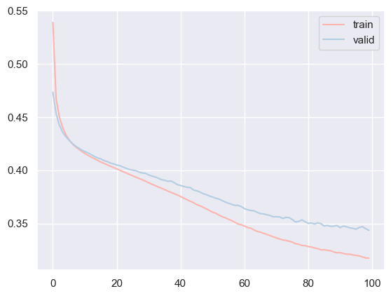

```python
# Capturing learning history per epoch
hist = pd.DataFrame(history1.history)
hist["epoch"] = history1.epoch

# Plotting accuracy at different epochs
plt.plot(hist["loss"])
plt.plot(hist["val_loss"])
plt.legend(("train", "valid"), loc=0)

## Complete the code to evaluate the model on X_test and y_test
results = model1.evaluate(X_test, y_test)
```

**Confusion matrix**

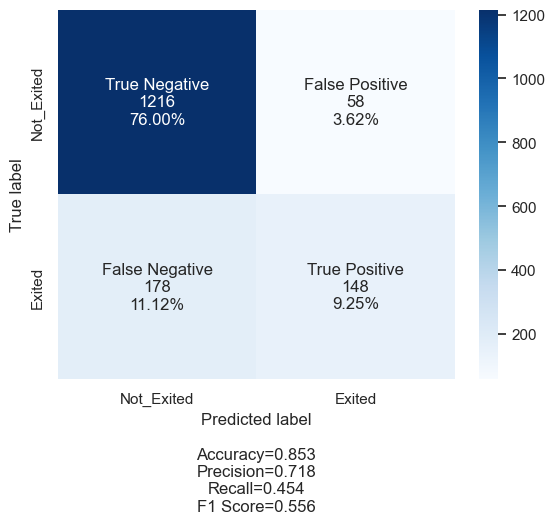

```python
## Complete the code to obtain the prediction on X_val and obtain the confusion matrix
y_pred1 = model1.predict(X_val)

# Let's predict using default threshold
y_pred1 = y_pred1 > 0.5
cm2 = confusion_matrix(y_val, y_pred1)
labels = ["True Negative", "False Positive", "False Negative", "True Positive"]
categories = ["Not_Exited", "Exited"]
make_confusion_matrix(cm2, group_names=labels, categories=categories, cmap="Blues")
```